# Rockchalk

meanCenter meanCenter

#### Description

meanCenter selectively centers or standarizes variables in a regression model.

#### Usage

meanCenter(model, centerOnlyInteractors = TRUE, centerDV = FALSE, standardize = FALSE, terms = NULL) ## Default S3 method: meanCenter(model, centerOnlyInteractors = TRUE, centerDV = FALSE, standardize = FALSE, terms = NULL) Arguments model a fitted regression model (presumably from lm) centerOnlyInteractors Default TRUE. If FALSE, all numeric predictors in the regression data frame are centered before the regression is conducted. centerDV Default FALSE. Should the dependent variable be centered? Do not set this option to TRUE unless the dependent variable is a numeric variable. Otherwise, it is an error. standardize Default FALSE. Instead of simply mean-centering the variables, should they also be “standardized” by first mean-centering and then dividing by the estimated standard deviation. terms Optional. A vector of variable names to be centered. Supplying this argument will stop meanCenter from searching for interaction terms that might need to be centered.

#### Examples

```r
library(rockchalk)
N <- 100
dat <- genCorrelatedData(N = N, means = c(100, 200), sds = c(20, 30),
rho = 0.4, stde = 10)
dat$x3 <- rnorm(100, m = 40, s = 4)
m1 <- lm(y ~ x1 * x2 + x3, data = dat)
summary(m1)
```

```
##
## Call:
## lm(formula = y ~ x1 * x2 + x3, data = dat)
##
## Residuals:
##      Min       1Q   Median       3Q      Max
## -26.1244  -5.8042   0.9257   7.2009  16.3036
##
## Coefficients:
##              Estimate Std. Error t value Pr(>|t|)
## (Intercept)  6.987631  26.531401   0.263   0.7928
## x1           0.271562   0.242332   1.121   0.2653
## x2           0.222124   0.124296   1.787   0.0771 .
## x3          -0.218562   0.276313  -0.791   0.4309
## x1:x2       -0.000462   0.001211  -0.381   0.7038
## ---
## Signif. codes:  0 '***' 0.001 '**' 0.01 '*' 0.05 '.' 0.1 ' ' 1
##
## Residual standard error: 9.549 on 95 degrees of freedom
## Multiple R-squared:  0.3986, Adjusted R-squared:  0.3733
## F-statistic: 15.74 on 4 and 95 DF,  p-value: 6.441e-10
```

```r
mcDiagnose(m1)
```

```
## The following auxiliary models are being estimated and returned in a list:
## x1 ~ x2 + x3 + `x1:x2`
## <environment: 0x000000000dee0d20>
## x2 ~ x1 + x3 + `x1:x2`
## <environment: 0x000000000dee0d20>
## x3 ~ x1 + x2 + `x1:x2`
## <environment: 0x000000000dee0d20>
## `x1:x2` ~ x1 + x2 + x3
## <environment: 0x000000000dee0d20>
## Drum roll please!
##
## And your R_j Squareds are (auxiliary Rsq)
##          x1          x2          x3       x1:x2
## 0.958532963 0.941203848 0.002613843 0.981161708
## The Corresponding VIF, 1/(1-R_j^2)
##        x1        x2        x3     x1:x2
## 24.115541 17.007916  1.002621 53.083370
## Bivariate Correlations for design matrix
##         x1   x2   x3 x1:x2
## x1    1.00 0.35 0.00  0.85
## x2    0.35 1.00 0.05  0.77
## x3    0.00 0.05 1.00  0.03
## x1:x2 0.85 0.77 0.03  1.00
```

```r
m1c <- meanCenter(m1)
summary(m1c)
```

```
## These variables were mean-centered before any transformations were made on the design matrix.
## [1] "x1c" "x2c"
## The centers and scale factors were
##          x1c      x2c
## mean  101.35 199.2883
## scale   1.00   1.0000
## The summary statistics of the variables in the design matrix (after centering).
##             mean std.dev.
## y        60.4189  12.0627
## x1c       0.0000  19.4489
## x2c       0.0000  31.8439
## x3       40.8560   3.4780
## x1c:x2c 212.5261 801.7427
##
## The following results were produced from:
## meanCenter.default(model = m1)
##
## Call:
## lm(formula = y ~ x1c * x2c + x3, data = stddat)
##
## Residuals:
##      Min       1Q   Median       3Q      Max
## -26.1244  -5.8042   0.9257   7.2009  16.3036
##
## Coefficients:
##              Estimate Std. Error t value Pr(>|t|)
## (Intercept) 69.446687  11.333237   6.128 2.01e-08 ***
## x1c          0.179499   0.052843   3.397 0.000997 ***
## x2c          0.175305   0.032288   5.429 4.33e-07 ***
## x3          -0.218562   0.276313  -0.791 0.430917
## x1c:x2c     -0.000462   0.001211  -0.381 0.703824
## ---
## Signif. codes:  0 '***' 0.001 '**' 0.01 '*' 0.05 '.' 0.1 ' ' 1
##
## Residual standard error: 9.549 on 95 degrees of freedom
## Multiple R-squared:  0.3986, Adjusted R-squared:  0.3733
## F-statistic: 15.74 on 4 and 95 DF,  p-value: 6.441e-10
```

```r
mcDiagnose(m1c)
```

```
## The following auxiliary models are being estimated and returned in a list:
## x1c ~ x2c + x3 + `x1c:x2c`
## <environment: 0x000000000bba1dd0>
## x2c ~ x1c + x3 + `x1c:x2c`
## <environment: 0x000000000bba1dd0>
## x3 ~ x1c + x2c + `x1c:x2c`
## <environment: 0x000000000bba1dd0>
## `x1c:x2c` ~ x1c + x2c + x3
## <environment: 0x000000000bba1dd0>
## Drum roll please!
##
## And your R_j Squareds are (auxiliary Rsq)
##         x1c         x2c          x3     x1c:x2c
## 0.127923031 0.128685379 0.002613843 0.023658485
## The Corresponding VIF, 1/(1-R_j^2)
##      x1c      x2c       x3  x1c:x2c
## 1.146688 1.147691 1.002621 1.024232
## Bivariate Correlations for design matrix
##           x1c   x2c    x3 x1c:x2c
## x1c      1.00  0.35  0.00   -0.13
## x2c      0.35  1.00  0.05   -0.12
## x3       0.00  0.05  1.00   -0.01
## x1c:x2c -0.13 -0.12 -0.01    1.00
```

```r
m2 <- lm(y ~ x1 * x2 + x3, data = dat)
summary(m2)
```

```
##
## Call:
## lm(formula = y ~ x1 * x2 + x3, data = dat)
##
## Residuals:
##      Min       1Q   Median       3Q      Max
## -26.1244  -5.8042   0.9257   7.2009  16.3036
##
## Coefficients:
##              Estimate Std. Error t value Pr(>|t|)
## (Intercept)  6.987631  26.531401   0.263   0.7928
## x1           0.271562   0.242332   1.121   0.2653
## x2           0.222124   0.124296   1.787   0.0771 .
## x3          -0.218562   0.276313  -0.791   0.4309
## x1:x2       -0.000462   0.001211  -0.381   0.7038
## ---
## Signif. codes:  0 '***' 0.001 '**' 0.01 '*' 0.05 '.' 0.1 ' ' 1
##
## Residual standard error: 9.549 on 95 degrees of freedom
## Multiple R-squared:  0.3986, Adjusted R-squared:  0.3733
## F-statistic: 15.74 on 4 and 95 DF,  p-value: 6.441e-10
```

```r
mcDiagnose(m2)
```

```
## The following auxiliary models are being estimated and returned in a list:
## x1 ~ x2 + x3 + `x1:x2`
## <environment: 0x0000000010922838>
## x2 ~ x1 + x3 + `x1:x2`
## <environment: 0x0000000010922838>
## x3 ~ x1 + x2 + `x1:x2`
## <environment: 0x0000000010922838>
## `x1:x2` ~ x1 + x2 + x3
## <environment: 0x0000000010922838>
## Drum roll please!
##
## And your R_j Squareds are (auxiliary Rsq)
##          x1          x2          x3       x1:x2
## 0.958532963 0.941203848 0.002613843 0.981161708
## The Corresponding VIF, 1/(1-R_j^2)
##        x1        x2        x3     x1:x2
## 24.115541 17.007916  1.002621 53.083370
## Bivariate Correlations for design matrix
##         x1   x2   x3 x1:x2
## x1    1.00 0.35 0.00  0.85
## x2    0.35 1.00 0.05  0.77
## x3    0.00 0.05 1.00  0.03
## x1:x2 0.85 0.77 0.03  1.00
```

```r
m2c <- meanCenter(m2, standardize = TRUE)
summary(m2c)
```

```
## These variables were mean-centered before any transformations were made on the design matrix.
## [1] "x1cs" "x2cs"
## The centers and scale factors were
##           x1cs      x2cs
## mean  101.3500 199.28826
## scale  19.4489  31.84391
## The summary statistics of the variables in the design matrix (after centering).
##               mean std.dev.
## y         60.41894 12.06274
## x1cs       0.00000  1.00000
## x2cs       0.00000  1.00000
## x3        40.85597  3.47795
## x1cs:x2cs  0.34316  1.29453
##
## The following results were produced from:
## meanCenter.default(model = m2, standardize = TRUE)
##
## Call:
## lm(formula = y ~ x1cs * x2cs + x3, data = stddat)
##
## Residuals:
##      Min       1Q   Median       3Q      Max
## -26.1244  -5.8042   0.9257   7.2009  16.3036
##
## Coefficients:
##             Estimate Std. Error t value Pr(>|t|)
## (Intercept)  69.4467    11.3332   6.128 2.01e-08 ***
## x1cs          3.4911     1.0277   3.397 0.000997 ***
## x2cs          5.5824     1.0282   5.429 4.33e-07 ***
## x3           -0.2186     0.2763  -0.791 0.430917
## x1cs:x2cs    -0.2861     0.7503  -0.381 0.703824
## ---
## Signif. codes:  0 '***' 0.001 '**' 0.01 '*' 0.05 '.' 0.1 ' ' 1
##
## Residual standard error: 9.549 on 95 degrees of freedom
## Multiple R-squared:  0.3986, Adjusted R-squared:  0.3733
## F-statistic: 15.74 on 4 and 95 DF,  p-value: 6.441e-10
```

```r
mcDiagnose(m2c)
```

```
## The following auxiliary models are being estimated and returned in a list:
## x1cs ~ x2cs + x3 + `x1cs:x2cs`
## <environment: 0x000000001106bd58>
## x2cs ~ x1cs + x3 + `x1cs:x2cs`
## <environment: 0x000000001106bd58>
## x3 ~ x1cs + x2cs + `x1cs:x2cs`
## <environment: 0x000000001106bd58>
## `x1cs:x2cs` ~ x1cs + x2cs + x3
## <environment: 0x000000001106bd58>
## Drum roll please!
##
## And your R_j Squareds are (auxiliary Rsq)
##        x1cs        x2cs          x3   x1cs:x2cs
## 0.127923031 0.128685379 0.002613843 0.023658485
## The Corresponding VIF, 1/(1-R_j^2)
##      x1cs      x2cs        x3 x1cs:x2cs
##  1.146688  1.147691  1.002621  1.024232
## Bivariate Correlations for design matrix
##            x1cs  x2cs    x3 x1cs:x2cs
## x1cs       1.00  0.35  0.00     -0.13
## x2cs       0.35  1.00  0.05     -0.12
## x3         0.00  0.05  1.00     -0.01
## x1cs:x2cs -0.13 -0.12 -0.01      1.00
```

```r
m2c2 <- meanCenter(m2, centerOnlyInteractors = FALSE)
summary(m2c2)
```

```
## These variables were mean-centered before any transformations were made on the design matrix.
## [1] "x1c" "x2c" "x3c"
## The centers and scale factors were
##          x1c      x2c      x3c
## mean  101.35 199.2883 40.85597
## scale   1.00   1.0000  1.00000
## The summary statistics of the variables in the design matrix (after centering).
##             mean std.dev.
## y        60.4189  12.0627
## x1c       0.0000  19.4489
## x2c       0.0000  31.8439
## x3c       0.0000   3.4780
## x1c:x2c 212.5261 801.7427
##
## The following results were produced from:
## meanCenter.default(model = m2, centerOnlyInteractors = FALSE)
##
## Call:
## lm(formula = y ~ x1c * x2c + x3c, data = stddat)
##
## Residuals:
##      Min       1Q   Median       3Q      Max
## -26.1244  -5.8042   0.9257   7.2009  16.3036
##
## Coefficients:
##              Estimate Std. Error t value Pr(>|t|)
## (Intercept) 60.517120   0.989037  61.188  < 2e-16 ***
## x1c          0.179499   0.052843   3.397 0.000997 ***
## x2c          0.175305   0.032288   5.429 4.33e-07 ***
## x3c         -0.218562   0.276313  -0.791 0.430917
## x1c:x2c     -0.000462   0.001211  -0.381 0.703824
## ---
## Signif. codes:  0 '***' 0.001 '**' 0.01 '*' 0.05 '.' 0.1 ' ' 1
##
## Residual standard error: 9.549 on 95 degrees of freedom
## Multiple R-squared:  0.3986, Adjusted R-squared:  0.3733
## F-statistic: 15.74 on 4 and 95 DF,  p-value: 6.441e-10
```

```r
m2c3 <- meanCenter(m2, centerOnlyInteractors = FALSE, centerDV = TRUE)
summary(m2c3)
```

```
## These variables were mean-centered before any transformations were made on the design matrix.
## [1] "yc"  "x1c" "x2c" "x3c"
## The centers and scale factors were
##             yc    x1c      x2c      x3c
## mean  60.41894 101.35 199.2883 40.85597
## scale  1.00000   1.00   1.0000  1.00000
## The summary statistics of the variables in the design matrix (after centering).
##             mean std.dev.
## yc        0.0000  12.0627
## x1c       0.0000  19.4489
## x2c       0.0000  31.8439
## x3c       0.0000   3.4780
## x1c:x2c 212.5261 801.7427
##
## The following results were produced from:
## meanCenter.default(model = m2, centerOnlyInteractors = FALSE,
##     centerDV = TRUE)
##
## Call:
## lm(formula = yc ~ x1c * x2c + x3c, data = stddat)
##
## Residuals:
##      Min       1Q   Median       3Q      Max
## -26.1244  -5.8042   0.9257   7.2009  16.3036
##
## Coefficients:
##              Estimate Std. Error t value Pr(>|t|)
## (Intercept)  0.098177   0.989037   0.099 0.921137
## x1c          0.179499   0.052843   3.397 0.000997 ***
## x2c          0.175305   0.032288   5.429 4.33e-07 ***
## x3c         -0.218562   0.276313  -0.791 0.430917
## x1c:x2c     -0.000462   0.001211  -0.381 0.703824
## ---
## Signif. codes:  0 '***' 0.001 '**' 0.01 '*' 0.05 '.' 0.1 ' ' 1
##
## Residual standard error: 9.549 on 95 degrees of freedom
## Multiple R-squared:  0.3986, Adjusted R-squared:  0.3733
## F-statistic: 15.74 on 4 and 95 DF,  p-value: 6.441e-10
```

```r
dat <- genCorrelatedData(N = N, means = c(100, 200), sds = c(20, 30),
rho = 0.4, stde = 10)
dat$x3 <- rnorm(100, m = 40, s = 4)
dat$x3 <- gl(4, 25, labels = c("none", "some", "much", "total"))
m3 <- lm(y ~ x1 * x2 + x3, data = dat)
summary(m3)
```

```
##
## Call:
## lm(formula = y ~ x1 * x2 + x3, data = dat)
##
## Residuals:
##      Min       1Q   Median       3Q      Max
## -21.8932  -5.7117  -0.1804   6.5123  19.7282
##
## Coefficients:
##               Estimate Std. Error t value Pr(>|t|)
## (Intercept) -54.323282  26.471815  -2.052 0.042969 *
## x1            0.834703   0.270044   3.091 0.002632 **
## x2            0.504600   0.138900   3.633 0.000459 ***
## x3some       -3.407210   2.658513  -1.282 0.203161
## x3much       -5.062818   2.598879  -1.948 0.054421 .
## x3total      -2.439497   2.679551  -0.910 0.364959
## x1:x2        -0.003267   0.001364  -2.395 0.018648 *
## ---
## Signif. codes:  0 '***' 0.001 '**' 0.01 '*' 0.05 '.' 0.1 ' ' 1
##
## Residual standard error: 9.156 on 93 degrees of freedom
## Multiple R-squared:  0.5114, Adjusted R-squared:  0.4798
## F-statistic: 16.22 on 6 and 93 DF,  p-value: 1.082e-12
```

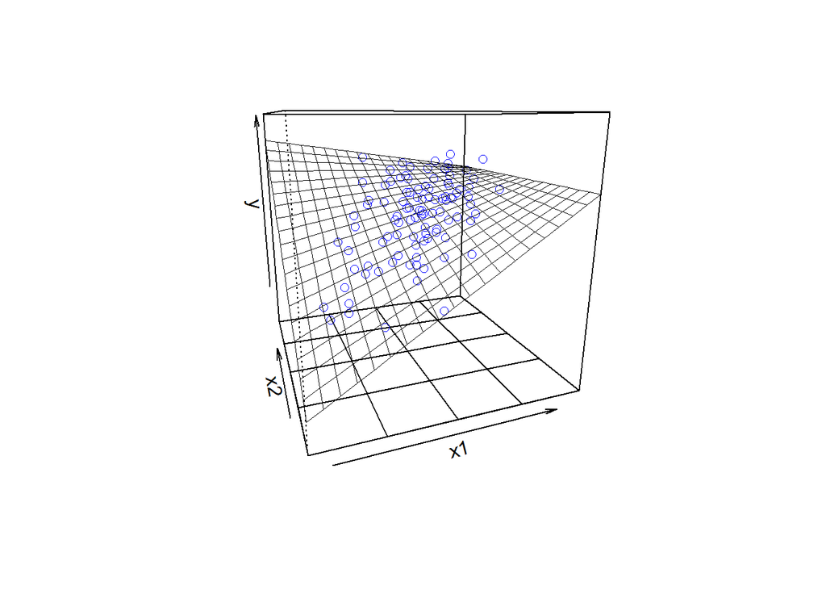

```r
## visualize, for fun
plotPlane(m3, "x1", "x2")
```

```r
m3c1 <- meanCenter(m3)
summary(m3c1)
```

```
## These variables were mean-centered before any transformations were made on the design matrix.
## [1] "x1c" "x2c"
## The centers and scale factors were
##            x1c      x2c
## mean  99.63131 201.8498
## scale  1.00000   1.0000
## The summary statistics of the variables in the design matrix (after centering).
##             mean std.dev.
## y        61.1350  12.6949
## x1c       0.0000  22.3583
## x2c       0.0000  30.9691
## x3some    0.2500   0.4352
## x3much    0.2500   0.4352
## x3total   0.2500   0.4352
## x1c:x2c 346.3576 709.2103
##
## The following results were produced from:
## meanCenter.default(model = m3)
##
## Call:
## lm(formula = y ~ x1c * x2c + x3, data = stddat)
##
## Residuals:
##      Min       1Q   Median       3Q      Max
## -21.8932  -5.7117  -0.1804   6.5123  19.7282
##
## Coefficients:
##              Estimate Std. Error t value Pr(>|t|)
## (Intercept) 64.993867   1.906730  34.087  < 2e-16 ***
## x1c          0.175283   0.049006   3.577 0.000555 ***
## x2c          0.179116   0.035687   5.019 2.49e-06 ***
## x3some      -3.407210   2.658513  -1.282 0.203161
## x3much      -5.062818   2.598879  -1.948 0.054421 .
## x3total     -2.439497   2.679551  -0.910 0.364959
## x1c:x2c     -0.003267   0.001364  -2.395 0.018648 *
## ---
## Signif. codes:  0 '***' 0.001 '**' 0.01 '*' 0.05 '.' 0.1 ' ' 1
##
## Residual standard error: 9.156 on 93 degrees of freedom
## Multiple R-squared:  0.5114, Adjusted R-squared:  0.4798
## F-statistic: 16.22 on 6 and 93 DF,  p-value: 1.082e-12
```

```r
## Not exactly the same as a "standardized" regression because the
## interactive variables are centered in the model frame,
## and the term "x1:x2" is never centered again.
m3c2 <- meanCenter(m3, centerDV = TRUE,
centerOnlyInteractors = FALSE, standardize = TRUE)
summary(m3c2)
```

```
## These variables were mean-centered before any transformations were made on the design matrix.
## [1] "ycs"  "x1cs" "x2cs"
## The centers and scale factors were
##            ycs     x1cs      x2cs
## mean  61.13498 99.63131 201.84983
## scale 12.69489 22.35831  30.96909
## The summary statistics of the variables in the design matrix (after centering).
##                mean  std.dev.
## ycs       0.0000000 1.0000000
## x1cs      0.0000000 1.0000000
## x2cs      0.0000000 1.0000000
## x3some    0.2500000 0.4351941
## x3much    0.2500000 0.4351941
## x3total   0.2500000 0.4351941
## x1cs:x2cs 0.5002157 1.0242537
##
## The following results were produced from:
## meanCenter.default(model = m3, centerOnlyInteractors = FALSE,
##     centerDV = TRUE, standardize = TRUE)
##
## Call:
## lm(formula = ycs ~ x1cs * x2cs + x3, data = stddat)
##
## Residuals:
##      Min       1Q   Median       3Q      Max
## -1.72456 -0.44992 -0.01421  0.51298  1.55403
##
## Coefficients:
##             Estimate Std. Error t value Pr(>|t|)
## (Intercept)  0.30397    0.15020   2.024 0.045857 *
## x1cs         0.30871    0.08631   3.577 0.000555 ***
## x2cs         0.43695    0.08706   5.019 2.49e-06 ***
## x3some      -0.26839    0.20942  -1.282 0.203161
## x3much      -0.39881    0.20472  -1.948 0.054421 .
## x3total     -0.19216    0.21107  -0.910 0.364959
## x1cs:x2cs   -0.17819    0.07441  -2.395 0.018648 *
## ---
## Signif. codes:  0 '***' 0.001 '**' 0.01 '*' 0.05 '.' 0.1 ' ' 1
##
## Residual standard error: 0.7212 on 93 degrees of freedom
## Multiple R-squared:  0.5114, Adjusted R-squared:  0.4798
## F-statistic: 16.22 on 6 and 93 DF,  p-value: 1.082e-12
```

```r
m3st <- standardize(m3)
summary(m3st)
```

```
## All variables in the model matrix and the dependent variable
## were centered. The centered variables have the letter "s" appended to their
## non-centered counterparts, even constructed
## variables like `x1:x2` and poly(x1,2). We agree, that's probably
## ill-advised, but you asked for it by running standardize().
##
## The rockchalk function meanCenter is a smarter option, probably.
##
## The summary statistics of the variables in the design matrix.
##          mean std.dev.
## ys          0        1
## x1s         0        1
## x2s         0        1
## x3somes     0        1
## x3muchs     0        1
## x3totals    0        1
## `x1:x2s`    0        1
##
## Call:
## lm(formula = ys ~ -1 + x1s + x2s + x3somes + x3muchs + x3totals +
##     `x1:x2s`, data = stddat)
##
## Residuals:
##      Min       1Q   Median       3Q      Max
## -1.72456 -0.44992 -0.01421  0.51298  1.55403
##
## Coefficients:
##          Estimate Std. Error t value Pr(>|t|)
## x1s       1.47008    0.47307   3.108 0.002495 **
## x2s       1.23097    0.33704   3.652 0.000427 ***
## x3somes  -0.11680    0.09065  -1.288 0.200736
## x3muchs  -0.17356    0.08862  -1.959 0.053133 .
## x3totals -0.08363    0.09137  -0.915 0.362379
## `x1:x2s` -1.67366    0.69523  -2.407 0.018022 *
## ---
## Signif. codes:  0 '***' 0.001 '**' 0.01 '*' 0.05 '.' 0.1 ' ' 1
##
## Residual standard error: 0.7174 on 94 degrees of freedom
## Multiple R-squared:  0.5114, Adjusted R-squared:  0.4802
## F-statistic:  16.4 on 6 and 94 DF,  p-value: 7.72e-13
```

```r
## Make a bigger dataset to see effects better
N <- 500
dat <- genCorrelatedData(N = N, means = c(200,200), sds = c(60,30),
rho = 0.2, stde = 10)
dat$x3 <- rnorm(100, m = 40, s = 4)
dat$x3 <- gl(4, 25, labels = c("none", "some", "much", "total"))
dat$y2 <- with(dat,
0.4 - 0.15 * x1 + 0.04 * x1^2 -
drop(contrasts(dat$x3)[dat$x3, ] %*% c(-1.9, 0, 5.1)) +
1000* rnorm(nrow(dat)))
dat$y2 <- drop(dat$y2)
m4literal <- lm(y2 ~ x1 + I(x1*x1) + x2 + x3, data = dat)
summary(m4literal)
```

```
##
## Call:
## lm(formula = y2 ~ x1 + I(x1 * x1) + x2 + x3, data = dat)
##
## Residuals:
##      Min       1Q   Median       3Q      Max
## -2744.04  -705.20     2.35   705.27  2992.13
##
## Coefficients:
##               Estimate Std. Error t value Pr(>|t|)
## (Intercept) 180.575927 465.008531   0.388    0.698
## x1           -1.366134   3.748160  -0.364    0.716
## I(x1 * x1)    0.042798   0.009159   4.673 3.84e-06 ***
## x2           -0.510984   1.493946  -0.342    0.732
## x3some       61.166438 129.104150   0.474    0.636
## x3much       61.603151 128.846611   0.478    0.633
## x3total     -82.800688 129.306350  -0.640    0.522
## ---
## Signif. codes:  0 '***' 0.001 '**' 0.01 '*' 0.05 '.' 0.1 ' ' 1
##
## Residual standard error: 1015 on 493 degrees of freedom
## Multiple R-squared:  0.4743, Adjusted R-squared:  0.4679
## F-statistic: 74.12 on 6 and 493 DF,  p-value: < 2.2e-16
```

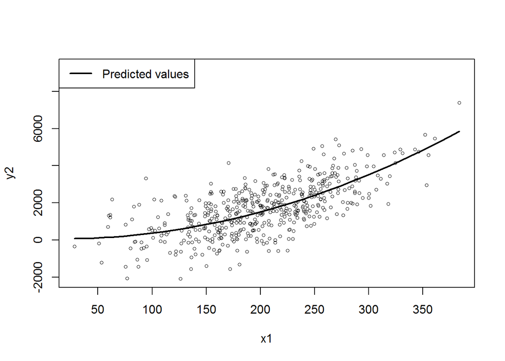

```r
plotCurves(m4literal, plotx="x1")
```

```r
## Superficially, there is multicollinearity (omit the intercept)

cor(model.matrix(m4literal)[ -1 , -1 ])
```

```
##                     x1  I(x1 * x1)          x2      x3some      x3much
## x1          1.00000000  0.97874014  0.15217689  0.03387612 -0.02037949
## I(x1 * x1)  0.97874014  1.00000000  0.14448726  0.01962635 -0.01328599
## x2          0.15217689  0.14448726  1.00000000 -0.01609170 -0.02814549
## x3some      0.03387612  0.01962635 -0.01609170  1.00000000 -0.33422460
## x3much     -0.02037949 -0.01328599 -0.02814549 -0.33422460  1.00000000
## x3total     0.01495796  0.01668702 -0.07245939 -0.33422460 -0.33422460
##                x3total
## x1          0.01495796
## I(x1 * x1)  0.01668702
## x2         -0.07245939
## x3some     -0.33422460
## x3much     -0.33422460
## x3total     1.00000000
```

```r
m4literalmc <- meanCenter(m4literal, terms = "x1")
summary(m4literalmc)
```

```
## These variables were mean-centered before any transformations were made on the design matrix.
## [1] "x1c"
## The centers and scale factors were
##            x1c
## mean  200.4118
## scale   1.0000
## The summary statistics of the variables in the design matrix (after centering).
##                  mean std.dev.
## y2           1685.105 1390.781
## x1c             0.000   59.356
## I(x1c * x1c) 3516.086 4971.661
## x2            197.875   31.011
## x3some          0.250    0.433
## x3much          0.250    0.433
## x3total         0.250    0.433
##
## The following results were produced from:
## meanCenter.default(model = m4literal, terms = "x1")
##
## Call:
## lm(formula = y2 ~ x1c + I(x1c * x1c) + x2 + x3, data = stddat)
##
## Residuals:
##      Min       1Q   Median       3Q      Max
## -2744.04  -705.20     2.35   705.27  2992.13
##
## Coefficients:
##                Estimate Std. Error t value Pr(>|t|)
## (Intercept)   1.626e+03  3.209e+02   5.065 5.77e-07 ***
## x1c           1.579e+01  7.753e-01  20.364  < 2e-16 ***
## I(x1c * x1c)  4.280e-02  9.159e-03   4.673 3.84e-06 ***
## x2           -5.110e-01  1.494e+00  -0.342    0.732
## x3some        6.117e+01  1.291e+02   0.474    0.636
## x3much        6.160e+01  1.288e+02   0.478    0.633
## x3total      -8.280e+01  1.293e+02  -0.640    0.522
## ---
## Signif. codes:  0 '***' 0.001 '**' 0.01 '*' 0.05 '.' 0.1 ' ' 1
##
## Residual standard error: 1015 on 493 degrees of freedom
## Multiple R-squared:  0.4743, Adjusted R-squared:  0.4679
## F-statistic: 74.12 on 6 and 493 DF,  p-value: < 2.2e-16
```

```r
m4literalmcs <- meanCenter(m4literal, terms = "x1", standardize = TRUE)
summary(m4literalmcs)
```

```
## These variables were mean-centered before any transformations were made on the design matrix.
## [1] "x1cs"
## The centers and scale factors were
##            x1cs
## mean  200.41182
## scale  59.35598
## The summary statistics of the variables in the design matrix (after centering).
##                     mean  std.dev.
## y2             1685.1053 1390.7813
## x1cs              0.0000    1.0000
## I(x1cs * x1cs)    0.9980    1.4111
## x2              197.8751   31.0109
## x3some            0.2500    0.4334
## x3much            0.2500    0.4334
## x3total           0.2500    0.4334
##
## The following results were produced from:
## meanCenter.default(model = m4literal, standardize = TRUE, terms = "x1")
##
## Call:
## lm(formula = y2 ~ x1cs + I(x1cs * x1cs) + x2 + x3, data = stddat)
##
## Residuals:
##      Min       1Q   Median       3Q      Max
## -2744.04  -705.20     2.35   705.27  2992.13
##
## Coefficients:
##                Estimate Std. Error t value Pr(>|t|)
## (Intercept)    1625.744    320.950   5.065 5.77e-07 ***
## x1cs            937.119     46.019  20.364  < 2e-16 ***
## I(x1cs * x1cs)  150.781     32.269   4.673 3.84e-06 ***
## x2               -0.511      1.494  -0.342    0.732
## x3some           61.166    129.104   0.474    0.636
## x3much           61.603    128.847   0.478    0.633
## x3total         -82.801    129.306  -0.640    0.522
## ---
## Signif. codes:  0 '***' 0.001 '**' 0.01 '*' 0.05 '.' 0.1 ' ' 1
##
## Residual standard error: 1015 on 493 degrees of freedom
## Multiple R-squared:  0.4743, Adjusted R-squared:  0.4679
## F-statistic: 74.12 on 6 and 493 DF,  p-value: < 2.2e-16
```

```r
m4 <- lm(y2 ~ poly(x1, 2, raw = TRUE) + x2 + x3, data = dat)
summary(m4)
```

```
##
## Call:
## lm(formula = y2 ~ poly(x1, 2, raw = TRUE) + x2 + x3, data = dat)
##
## Residuals:
##      Min       1Q   Median       3Q      Max
## -2744.04  -705.20     2.35   705.27  2992.13
##
## Coefficients:
##                            Estimate Std. Error t value Pr(>|t|)
## (Intercept)              180.575927 465.008531   0.388    0.698
## poly(x1, 2, raw = TRUE)1  -1.366134   3.748160  -0.364    0.716
## poly(x1, 2, raw = TRUE)2   0.042798   0.009159   4.673 3.84e-06 ***
## x2                        -0.510984   1.493946  -0.342    0.732
## x3some                    61.166438 129.104150   0.474    0.636
## x3much                    61.603151 128.846611   0.478    0.633
## x3total                  -82.800688 129.306350  -0.640    0.522
## ---
## Signif. codes:  0 '***' 0.001 '**' 0.01 '*' 0.05 '.' 0.1 ' ' 1
##
## Residual standard error: 1015 on 493 degrees of freedom
## Multiple R-squared:  0.4743, Adjusted R-squared:  0.4679
## F-statistic: 74.12 on 6 and 493 DF,  p-value: < 2.2e-16
```

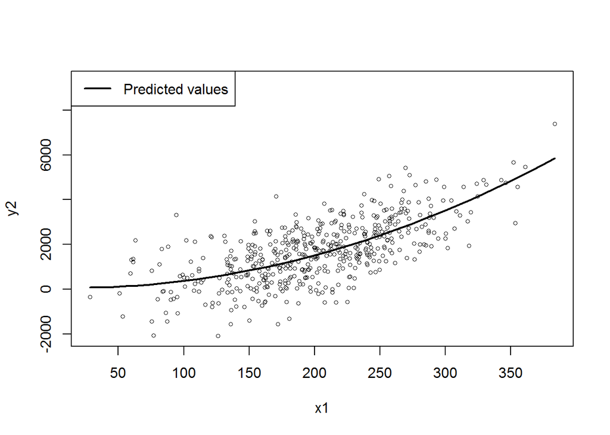

```r
plotCurves(m4, plotx="x1")
```

```r
m4mc1 <- meanCenter(m4, terms = "x1")
summary(m4mc1)
```

```
## These variables were mean-centered before any transformations were made on the design matrix.
## [1] "x1c"
## The centers and scale factors were
##            x1c
## mean  200.4118
## scale   1.0000
## The summary statistics of the variables in the design matrix (after centering).
##                               mean std.dev.
## y2                        1685.105 1390.781
## poly(x1c, 2, raw = TRUE)1    0.000   59.356
## poly(x1c, 2, raw = TRUE)2 3516.086 4971.661
## x2                         197.875   31.011
## x3some                       0.250    0.433
## x3much                       0.250    0.433
## x3total                      0.250    0.433
##
## The following results were produced from:
## meanCenter.default(model = m4, terms = "x1")
##
## Call:
## lm(formula = y2 ~ poly(x1c, 2, raw = TRUE) + x2 + x3, data = stddat)
##
## Residuals:
##      Min       1Q   Median       3Q      Max
## -2744.04  -705.20     2.35   705.27  2992.13
##
## Coefficients:
##                             Estimate Std. Error t value Pr(>|t|)
## (Intercept)                1.626e+03  3.209e+02   5.065 5.77e-07 ***
## poly(x1c, 2, raw = TRUE)1  1.579e+01  7.753e-01  20.364  < 2e-16 ***
## poly(x1c, 2, raw = TRUE)2  4.280e-02  9.159e-03   4.673 3.84e-06 ***
## x2                        -5.110e-01  1.494e+00  -0.342    0.732
## x3some                     6.117e+01  1.291e+02   0.474    0.636
## x3much                     6.160e+01  1.288e+02   0.478    0.633
## x3total                   -8.280e+01  1.293e+02  -0.640    0.522
## ---
## Signif. codes:  0 '***' 0.001 '**' 0.01 '*' 0.05 '.' 0.1 ' ' 1
##
## Residual standard error: 1015 on 493 degrees of freedom
## Multiple R-squared:  0.4743, Adjusted R-squared:  0.4679
## F-statistic: 74.12 on 6 and 493 DF,  p-value: < 2.2e-16
```

```r
m4mc2 <- meanCenter(m4, terms = "x1", standardize = TRUE)
summary(m4mc2)
```

```
## These variables were mean-centered before any transformations were made on the design matrix.
## [1] "x1cs"
## The centers and scale factors were
##            x1cs
## mean  200.41182
## scale  59.35598
## The summary statistics of the variables in the design matrix (after centering).
##                                 mean  std.dev.
## y2                         1685.1053 1390.7813
## poly(x1cs, 2, raw = TRUE)1    0.0000    1.0000
## poly(x1cs, 2, raw = TRUE)2    0.9980    1.4111
## x2                          197.8751   31.0109
## x3some                        0.2500    0.4334
## x3much                        0.2500    0.4334
## x3total                       0.2500    0.4334
##
## The following results were produced from:
## meanCenter.default(model = m4, standardize = TRUE, terms = "x1")
##
## Call:
## lm(formula = y2 ~ poly(x1cs, 2, raw = TRUE) + x2 + x3, data = stddat)
##
## Residuals:
##      Min       1Q   Median       3Q      Max
## -2744.04  -705.20     2.35   705.27  2992.13
##
## Coefficients:
##                            Estimate Std. Error t value Pr(>|t|)
## (Intercept)                1625.744    320.950   5.065 5.77e-07 ***
## poly(x1cs, 2, raw = TRUE)1  937.119     46.019  20.364  < 2e-16 ***
## poly(x1cs, 2, raw = TRUE)2  150.781     32.269   4.673 3.84e-06 ***
## x2                           -0.511      1.494  -0.342    0.732
## x3some                       61.166    129.104   0.474    0.636
## x3much                       61.603    128.847   0.478    0.633
## x3total                     -82.801    129.306  -0.640    0.522
## ---
## Signif. codes:  0 '***' 0.001 '**' 0.01 '*' 0.05 '.' 0.1 ' ' 1
##
## Residual standard error: 1015 on 493 degrees of freedom
## Multiple R-squared:  0.4743, Adjusted R-squared:  0.4679
## F-statistic: 74.12 on 6 and 493 DF,  p-value: < 2.2e-16
```

```r
m4mc3 <- meanCenter(m4, terms = "x1", centerDV = TRUE, standardize = TRUE)
summary(m4mc3)
```

```
## These variables were mean-centered before any transformations were made on the design matrix.
## [1] "y2cs" "x1cs"
## The centers and scale factors were
##           y2cs      x1cs
## mean  1685.105 200.41182
## scale 1390.781  59.35598
## The summary statistics of the variables in the design matrix (after centering).
##                                mean std.dev.
## y2cs                         0.0000  1.00000
## poly(x1cs, 2, raw = TRUE)1   0.0000  1.00000
## poly(x1cs, 2, raw = TRUE)2   0.9980  1.41115
## x2                         197.8751 31.01095
## x3some                       0.2500  0.43345
## x3much                       0.2500  0.43345
## x3total                      0.2500  0.43345
##
## The following results were produced from:
## meanCenter.default(model = m4, centerDV = TRUE, standardize = TRUE,
##     terms = "x1")
##
## Call:
## lm(formula = y2cs ~ poly(x1cs, 2, raw = TRUE) + x2 + x3, data = stddat)
##
## Residuals:
##      Min       1Q   Median       3Q      Max
## -1.97302 -0.50706  0.00169  0.50710  2.15140
##
## Coefficients:
##                              Estimate Std. Error t value Pr(>|t|)
## (Intercept)                -0.0426817  0.2307695  -0.185    0.853
## poly(x1cs, 2, raw = TRUE)1  0.6738079  0.0330887  20.364  < 2e-16 ***
## poly(x1cs, 2, raw = TRUE)2  0.1084148  0.0232019   4.673 3.84e-06 ***
## x2                         -0.0003674  0.0010742  -0.342    0.732
## x3some                      0.0439799  0.0928285   0.474    0.636
## x3much                      0.0442939  0.0926433   0.478    0.633
## x3total                    -0.0595354  0.0929739  -0.640    0.522
## ---
## Signif. codes:  0 '***' 0.001 '**' 0.01 '*' 0.05 '.' 0.1 ' ' 1
##
## Residual standard error: 0.7295 on 493 degrees of freedom
## Multiple R-squared:  0.4743, Adjusted R-squared:  0.4679
## F-statistic: 74.12 on 6 and 493 DF,  p-value: < 2.2e-16
```

Details

Works with “lm” class objects, objects estimated by glm(). This centers some or all of the the predictors and then re-fits the original model with the new variables. This is a convenience to researchers who are often urged to center their predictors. This is sometimes suggested as a way to ameliorate multi-collinearity in models that include interaction terms (Aiken and West, 1991; Cohen, et al 2002). Mean-centering may enhance interpretation of the regression intercept, but it actually does not help with multicollinearity. (Echambadi and Hess, 2007). This function facilitates comparison of mean-centered models with others by calculating centered variables. The defaults will cause a regressionâs numeric interactive variables to be mean centered. Variations on the arguments are discussed in details.

The user can claim control over which variables are centered in several ways. Most directly, by specifying a vector of variable names, the user can claim direct control. For example, the argument terms=c(“x1”,“x2”,“x3”) would cause 3 predictors to be centered. If one wants all predictors to be centered, the argument centerOnlyInteractors should be set to FALSE. Please note, this WILL NOT center factor variables. But it will find all numeric predictors and center them.

The dependent variable will not be centered, unless the user explicitly requests it by setting centerDV = TRUE.

As an additional convenience to the user, the argument standardize = TRUE can be used. This will divide each centered variable by its observed standard deviation. For people who like standardized regression, I suggest this is a better approach than the standardize function (which is brain-dead in the style of SPSS). meanCenter with standardize = TRUE will only try to standardize the numeric predictors.

To be completely clear, I believe mean-centering is not helpful with the multicollinearity problem. It doesnât help, it doesnât hurt. Only a misunderstanding leads its proponents to claim otherwise. This is emphasized in the vignette “rockchalk” that is distributed with this package.

#### Value

A regression model of the same type as the input model, with attributes representing the names of the centered variables. Author(s) Paul E. Johnson pauljohn@ku.edu References Aiken, L. S. and West, S.G. (1991). Multiple Regression: Testing and Interpreting Interactions. Newbury Park, Calif: Sage Publications. Cohen, J., Cohen, P.,West, S. G., and Aiken, L. S. (2002). Applied Multiple Regression/Correlation Analysis for the Behavioral Sciences (Third.). Routledge Academic. Echambadi, R., and Hess, J. D. (2007). Mean-Centering Does Not Alleviate Collinearity Problems in Moderated Multiple Regression Models. Marketing Science, 26(3), 438-445. See Also standardize residualCenter